# Sprzedaż ze względu na warunki pogodowe i wojenne

Autorzy

Andrii Yanishevskyi

Aleksey Myshko

$\newcommand{\unit}[1]{\,\mathrm{#1}}$

# Wstęp

## Idea

Projekt ten ma na celu zbadanie sprzedaży w dwóch sklepach artykułów gospodarstwa domowego zlokalizowanych w Kijowie w latach 2022–2025. Mając też dane o pogodzie, alarmach powietrznych i ostrzałach w tej miejscowości w danym okresie celem jest zbadanie ukrytych związków pomiędzy tymi cechami.

## Cele

Zbadać związki w rozkładzie dziennego przychodu oraz znaleźć zależności w strukturze ostrzałów, a konkretnie mamy wstępne hipotezy:

- Dzienny przychód z opłat kartą jest większy niż z opłat gotówką
- Sprzedaż zależy od dnia tygodnia i pory dnia (rano, dzień, wieczór)
- Sprzedaż jest skorelowana z pewnymi czynnikami pogodowymi i intensywnością ostrzałów
- Długość alarmów powietrznych zależy od pogody

## Dane

### Sprzedaż

Dane z obu sklepów zostały wyeksportowane z systemu [Checkbox](https://checkbox.ua/)

Zakres dostępnych danych transakcyjnych ze sklepów:

- sklep `A` w latach 2022-2025
- sklep `B` jedynie w 2025 roku

### Pogoda

Skorzystano z otwartego API serwisu [Open Meteo](https://open-meteo.com/). Pobrano dane odpowiednich okresów zgodnie z lokalizacją każdego ze sklepów co do:

- Temperatury
- Widoczności
- Opadów
- Wilgotności
- Ciśnienia

Po połączeniu dane wyglądają tak:

| datetime | payment | total | temperature_2m | visibility | precipitation | relative_humidity_2m | surface_pressure |
| --- | --- | --- | --- | --- | --- | --- | --- |
| 2024-01-02 11:12:18 | Cash | 120 | 0.8 | 22240 | 0 | 76 | 992.1 |
| 2024-01-02 11:43:00 | Card | 238 | 0.8 | 22240 | 0 | 76 | 992.1 |
| 2024-01-02 11:49:38 | Cash | 100 | 0.8 | 22240 | 0 | 76 | 992.1 |
| 2024-01-02 12:31:34 | Card | 565 | 0.4 | 24140 | 0 | 76 | 992.4 |
| 2024-01-02 12:58:50 | Cash | 75 | 0.4 | 24140 | 0 | 76 | 992.4 |

Zmienne ze sklepu:

- `datetime` — data i czas wystawienia paragonu
- `payment` — typ płatności – karta lub gotówka
- `total` — kwota łączna paragonu, UAH

Zmienne pogodowe w lokalizacji sklepu na początku godziny transakcji:

- `temperature_2m` — temperatura na wysokości $2 \unit{m}$, °C
- `visibility` — widoczność $\unit{m}$
- `precipitation` — opady $\unit{mm}$
- `relative_humidity_2m` — wilgotność względna $\%$
- `surface_pressure` — ciśnienie $\unit{hPa}$

### Alarmy

Zeskrapowano ze strony [kyiv.digital](https://kyiv.digital/storage/air-alert/stats.html). Następnie dla każdego dnia obliczono długość całkowitą alarmów – `length`($\unit{h}$). Dane przedstawiono w tabeli:

| day | length |
| --- | --- |
| 2022-02-28 | 6.000000 |
| 2022-03-01 | 5.150000 |
| 2022-03-02 | 5.316667 |
| 2022-03-03 | 8.250000 |
| 2022-03-04 | 6.266667 |

### Ostrzały

Zeskrapowano z [tabeli w artykule na Wikipedii](https://uk.wikipedia.org/wiki/%D0%9E%D0%B1%D1%81%D1%82%D1%80%D1%96%D0%BB%D0%B8_%D0%9A%D0%B8%D1%94%D0%B2%D0%B0#2024_%D1%80%D1%96%D0%BA). Po czyszczeniu mamy zbiór danych:

| date | Injured | Deaths | count |
| --- | --- | --- | --- |
| 2024-01-02 | 54 | 4 | 7 |
| 2024-01-23 | 8 | 1 | 3 |
| 2024-02-07 | 39 | 6 | 3 |
| 2024-03-21 | 10 | 0 | 4 |
| 2024-03-25 | 10 | 0 | 1 |

gdzie:

- `Injured` — liczba osób rannych w wyniku ostrzałów danego dnia
- `Deaths` — liczba osób zabitych w wyniku ostrzałów danego dnia
- `count` — liczba lokalizacji przylotów

# Wizualizacje

## Miesiące

Zobaczmy najpierw czy istnieje trend co do dnia pory roku, a właściwie miesiąca:

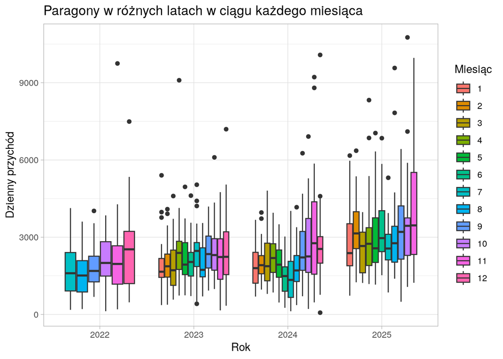

Obserwujemy wyraźną różnicę, zwłaszcza w roku 2024, pomiędzy latem a innymi porami roku. Właśnie z tego powodu, a też dlatego, że dane o ostrzałach są pełne tylko z tego okresu, skupimy się na analizie danych ze sklepu `A` w roku 2024.

### Dzień tygodnia

Sprawdźmy rozkład przychodu w zależności od dnia tygodnia (działamy już na danych tylko z 2024 roku)

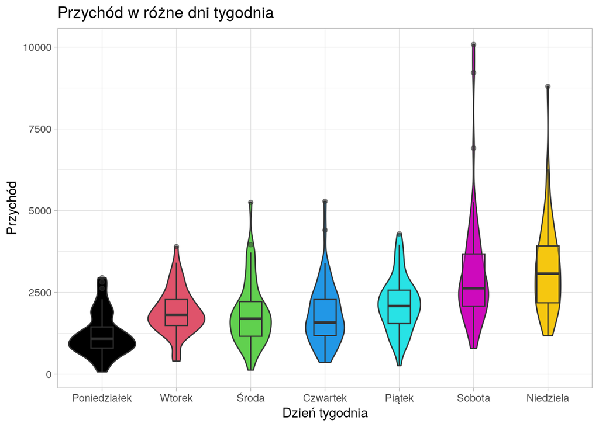

Obserwujemy obniżenie sprzedaży w poniedziałek. Mamy na to wyjaśnienie z rzeczywistości. Obok tego sklepu znajduje się targ który jest nieczynny w poniedziałek. Duża część klientów naszego sklepu są także klientami targu, a więc przy zamknięciu ostatniego sukces dzienny maleje.

Z innej strony w weekendy mamy o wiele lepsze wyniki dlatego, że ludzie naturalnie chodzą na zakupy częściej w dni wolne od pracy.

### Pory dnia

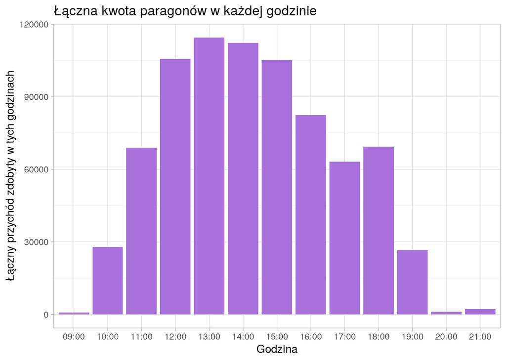

Na prawach subiektywnej decyzji badacza przypisujemy obserwacjom czas doby:

- Rano: `morning` – $t \in [0, 11)$
- Dzień: `day` – $t \in [11, 16)$
- Wieczór: `afternoon` – $t \in [16, 24)$

# Metody statystyczne

## Karta vs. gotówka

Zbadajmy najpierw czy kartą płacą więcej niż gotówka. Według doświadczenia własnego właścicielki sklepu po zainstalowaniu terminala płatniczego, średnia kwota paragonu wyrosła. Zobaczmy więc co mówią dane

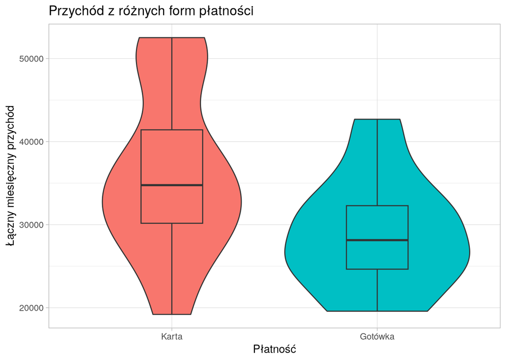

Obserwujemy istotną różnicę w kwotach zapłaconych kartą i gotówką. Sprawdźmy to za pomocą testu t-Studenta. Najpierw sprawdzamy za pomocą testu Shapiro-Wilka czy spełnione jest założenie tego testu – normalność rozkładów w obu grupach.

Stawiamy hipotezy:

- $H_0$: rozkład kwoty płatności kartą (gotówką) jest normalny
- $H_1$: rozkład tej cechy jest inny niż normalny

Dla obu testów otrzymano p-wartość mniejszą od dowolnego rozsądnie przyjętego poziomu istotności: $2.4 \times 10^{-19}$ i $1.4 \times 10^{-15}$ odpowiednio dla karty i gotówki. Odrzucamy hipotezę zerową – **rozkład obu cech jest inny niż normalny**. Jednak ze względu na to że mamy odpowiednio dużą próbę (355 obserwacji), pozwolimy sobie na przeprowadzenie testu mimo nie spełnionego założenia.

Dalej sprawdzamy czy wariancje są równe w grupach

$$H_0: \sigma_k = \sigma_g \quad
\text{vs} \quad
H_1: \sigma_k \ne \sigma_g$$

p-wartość jest równa 0. Odrzucamy $H_0$ – wariancje są różne. Wobec tego skorzystajmy z testu t-Welch’a, który jest odporny na różność wariancji

Stawiamy hipotezy:
$$H_0: \mu_k = \mu_g \quad
\text{vs} \quad
H_1: \mu_k > \mu_g$$

gdzie $\mu_k$ i $\mu_g$ to średnie rozkładu łącznego dziennego przychodu poprzez odpowiednio zapłatę kartą i gotówką

Otrzymano p-wartóść równą $3.8 \times 10^{-5}$, więc odrzucamy hipotezę zerową na korzyść hipotezy alternatywnej – **kartą średnio dziennie płacą więcej niż gotówką**.

Dodatkowo zbudowano przedział ufności dla różnicy $\mu_k - \mu_g$ na poziomie ufności 0.95 równy
$$[143.6976512 ; \; +\infty )$$
Przedział ten nie zawiera zera oraz jego lewy koniec jest dodatni, co potwierdza powyższy wniosek.

## Pory dnia

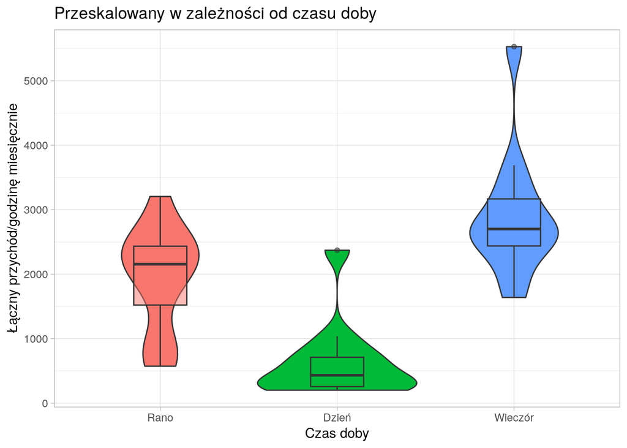

## Róznica w dniach tygodnia

Rozważmy teraz trzy grupy: poniedziałek, wtorek-piątek, sobota-niedziela. Z wykresu możemy przypuścić, że średnie przychodu w tych grupach istotnie się różnią. Ponieważ nie mamy normalności w żadnej z grup, przeprowadzimy odporny na to test Kruskala-Wallisa. Jest to test nieparametryczny z hipotezami:

$$H_0: F_1 = F_2 = F_3 = F \quad \text{vs} \quad
H_1: \bigvee_{\substack{i, j \in \{1, 2, 3\}\\ i\ne j}} F_i \ne F_j$$

gdzie $F_i$ – dystrybuanta rozkładu przychodu w $i$-tej grupie

Otrzymano p-wartość równą $1.9 \times 10^{-22}$, co oznacza że musimy odrzucić $H_0$ – **istnieje statystycznie istotna różnica między rozkładami przychodu w grupach**.

Przeprowadzamy też testy Welch’a post-hoc, dla każdej pary grup. W każdym przypadku odrzucamy hipotezę zerową o równości średnich, co oznacza, że **każda z tych par jest statystycznie istotnie zróżnicowana** ze względu na cechę przychód. Budujemy też przedziały ufności dla średniej w każdej z grup. Sprawdzamy najpierw normalność w grupach – od tego zależeć będzie jakiego wzoru na przedział ufności należy użyć.

Wyniki testów Shapiro-Wilka w grupach

|  | p-wartość |
| --- | --- |
| Poniedziałek | 0.0125608 |
| Wtorek-Piątek | 0.0000202 |
| Sobota-Niedziela | 0.0000000 |

Widzimy, że w każdej z grup odrzucamy hipotezę zerową o tym, że rozkład przychodu jest normalny. Skorzystano więc z przedziałów odpornych na naruszenie normalności rozkładu:
$$(\overline{x} - u_{1 - \frac{\alpha}{2}}\frac{\hat{s}}{\sqrt{n}}, \;
\overline{x} - u_{1 + \frac{\alpha}{2}}\frac{\hat{s}}{\sqrt{n}})$$

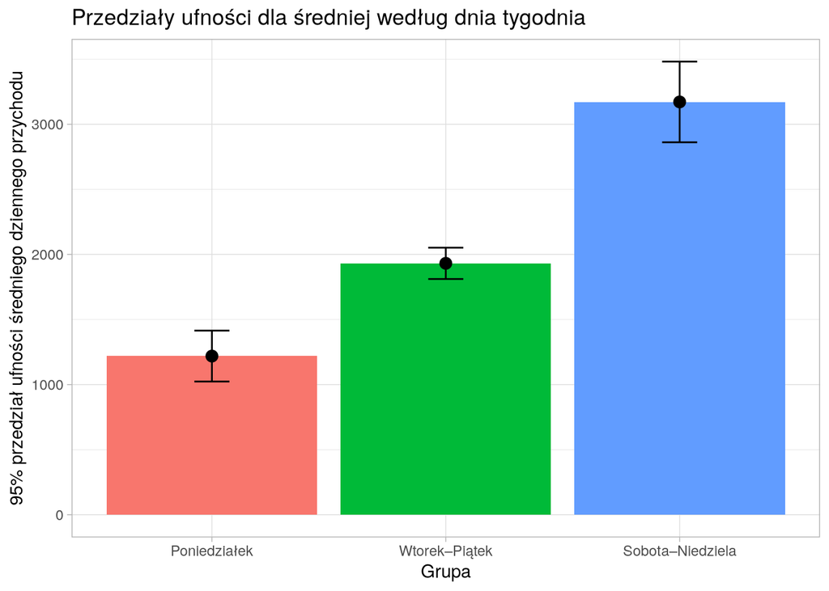

## Badanie korelacji

Przejdźmy teraz do wyjaśnienia tych wariancji przychodu, które wcześniej odkryliśmy. Zobaczmy jaka jest korelacja dostępnych cech ilościowych

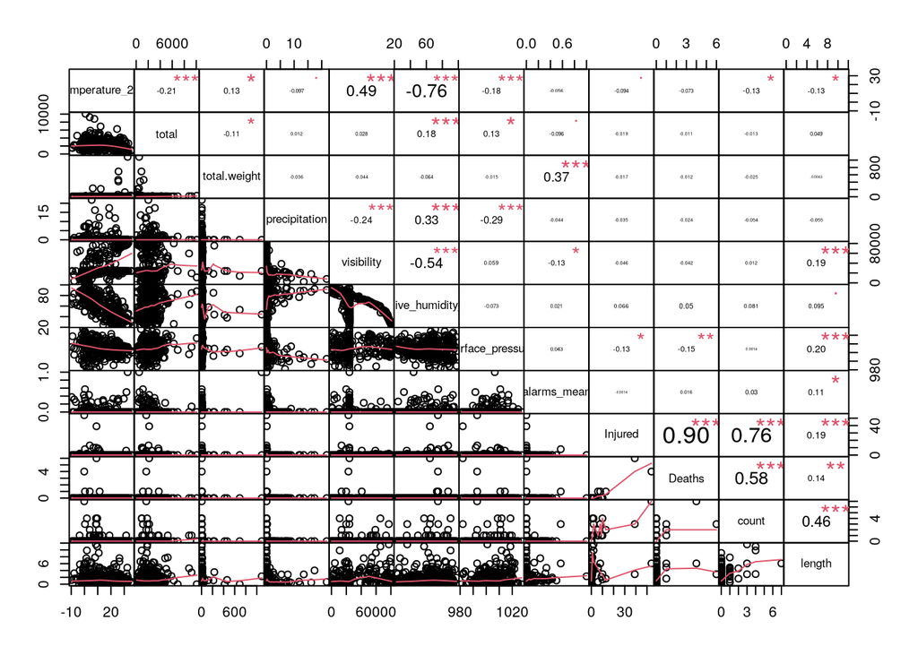

# Modele liniowe

### Model przychodu względem pozostałych cech

Doboru zmiennych do modelu dokonano metodą regresji krokowej. Zaczęto od modelu pustego, decyzję podejmowano na podstawie kryterium informacyjnego Akaike. Otrzymano model postaci:

```
total ~ temperature_2m + Injured + count + length + weekday +
    month + shellings
```

Wszystkie współczynniki tego modelu są statystycznie istotne (przy przyjętym poziomie istotności $\alpha = 0.01$) oraz poprawiony współczynnik determinacji jest równy:

$$R^2_{\text{adj}} \approx 0.416$$
Czyli model **wyjaśnia około 42% wariancji przychodu.** Nie jest to zadowalający wynik, ale jest on najlepszy z osiągalnych pod warunkiem danych które posiadamy.

Zwizualizujmy jeszcze korelację pomiędzy zmiennymi ilościowymi w otrzymanym modelu:

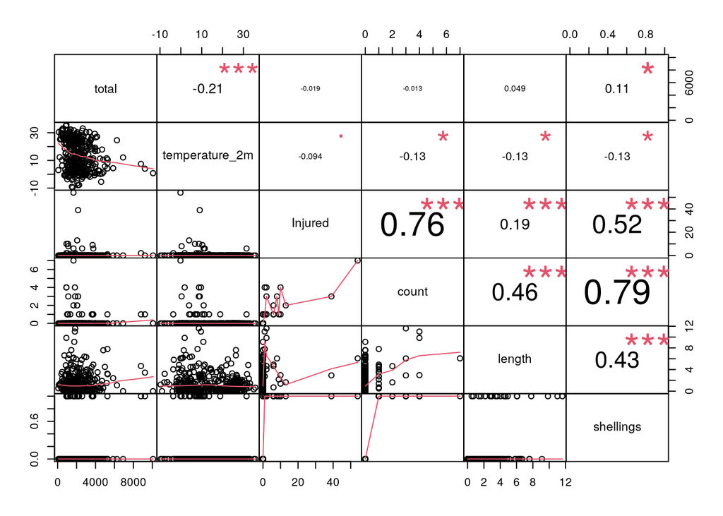

Istotnie skorelowane ze zmienną objaśnianą są tylko `temperature_2m` oraz `shellings`

### Model regresji logitowej

Spróbujmy teraz przewidzieć prawdopodobieństwo wystąpienia ostrzału w danym dniu na podstawie obecnych danych. Budujemy w tym celu model regresji logitowej z dychotomiczną zmienną objaśnianą `shellings`:

$$\text{shellings} =
\begin{cases}
1, & \text{count} >0\\
0, & \text{count} = 0
\end{cases}$$

Zbudowany model jest postaci:

```
shellings ~ length + visibility + surface_pressure + alarms_mean
```

Obliczamy powszechnie używane do walidacji modeli logitowych współczynniki pseudo $R^2$:

| McFadden | CoxSnell | Nagelkerke | Efron |
| --- | --- | --- | --- |
| 0.2620446 | 0.1110633 | 0.3068833 | 0.1933703 |

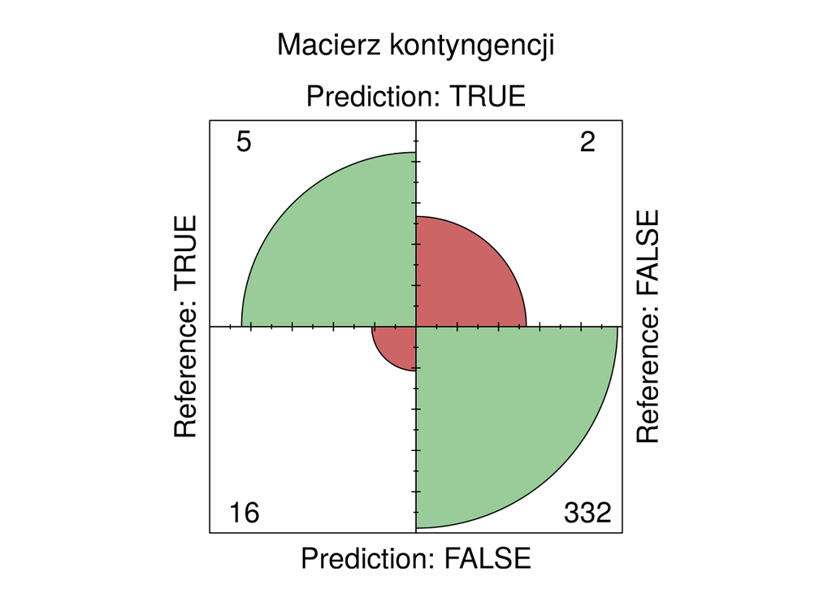

Obliczamy na podstawie tej macierzy też podstawowe miary:

Podstawowe miary modelu

| Dokładność | 0.949 |
| --- | --- |
| Czułość | 0.238 |
| Swoistość | 0.994 |
| Precyzja | 0.714 |

Wysoka wartość dokładności wskazuje na to, że większość obserwacji model **sklasyfikował poprawnie** , a swoistości – na to, że model wychwytuje większość dni w których **nie** było ostrzałów. Wówczas czułość jest za niska, co oznacza że model **nie jest dobry** w predykcji dni w których ostrzały wystąpią. Precyzja jest na przeciętnym poziomie, tzn ze wszystkich dni, dla których model przewidział ostrzał, blisko **3 na 4 faktycznie go miały** .

# Podsumowanie

Z badań statystycznych możemy wywnioskować:

Podjęta próba wyjaśnienia zachowań w tych danych okazała się częściowo skuteczna; w niektórych obszarach napotkaliśmy trudności, a w innych prawdopodobnie szukaliśmy zależności, które w rzeczywistości nie występują.

> If you torture the data long enough, it will confess to anything

> Ronald H. Coase